# Task 7

# Prerequisites

## Import libraries

```r
library(dplyr)
```

```r
library(ggplot2)
library(car)
library(rstatix)
```

## Import datasets

```r
urlP <- "https://raw.githubusercontent.com/WHPAN0108/BHT-DataScience-S24/main/data_clean/data/patient_info.csv"
urlH <- "https://raw.githubusercontent.com/WHPAN0108/BHT-DataScience-S24/main/data_clean/data/date.csv"

patients <- read.csv(urlP)
hospital <- read.csv(urlH)

head(patients)
```

|  | Participant_ID | Sex | Age | Smoking_status | BMI | Disease |
| --- | --- | --- | --- | --- | --- | --- |
| 1 | 1003300 | Male | 62 | Previous | 33.7597 | 2 |
| 2 | 1004025 | Male | 60 | Previous | 28.1173 | 1 |
| 3 | 1005551 | Male | 69 | Previous | 26.4159 | 2 |
| 4 | 1005594 | Male | 64 | Previous | 24.7550 | 1 |
| 5 | 1005624 | Male | 64 | Previous | 35.0773 | 2 |
| 6 | 1008540 | Female | 64 | Previous | 21.6764 | 2 |

```r
head(hospital)
```

|  | Participant_ID | VisitDate |
| --- | --- | --- |
| 1 | 1003300 | 1/7/2022 |
| 2 | 1003300 | 27/10/2021 |
| 3 | 1004025 | 19/05/2010 |
| 4 | 1005551 | 25/08/2021 |
| 5 | 1005551 | 29/06/2021 |
| 6 | 1005594 | 27/01/2020 |

# Data Clean & EDA

## Task 1

### Replace missing BMI values with the median BMI for the corresponding gender.

Calculate the BMI for male and female seperately. Exclude na-values.

```r
BMImaleMedian <- median( (subset(patients, Sex %in% c('Male') & !is.na(BMI))$BMI ) )
BMIfemaleMedian <- median( (subset(patients, Sex %in% c('Female') & !is.na(BMI))$BMI ) )

print(sprintf("Male median BMI is: %f and female median BMI is: %g", BMImaleMedian, BMIfemaleMedian))
```

```
## [1] "Male median BMI is: 28.245100 and female median BMI is: 28.0829"
```

Replace BMI values that are na and check afterwards, if any na values for BMI are left.

```r
patients$BMI[patients$Sex %in% c('Male') & is.na(patients$BMI)] <- BMImaleMedian
patients$BMI[patients$Sex %in% c('Female') & is.na(patients$BMI)] <- BMIfemaleMedian
subset(patients, is.na(BMI))
```

| Participant_ID | Sex | Age | Smoking_status | BMI | Disease |
| --- | --- | --- | --- | --- | --- |

## Task 2

### Perform a sanity check on all columns in both files, and remove any samples that do not pass.

#### patients

Do a summary and check for unusual or unrealistic values.

```r
summary(patients)
```

```
##  Participant_ID        Sex                 Age        Smoking_status
##  Min.   :1003300   Length:2216        Min.   : 6.00   Length:2216
##  1st Qu.:2338796   Class :character   1st Qu.:58.00   Class :character
##  Median :3591072   Mode  :character   Median :63.00   Mode  :character
##  Mean   :3557200                      Mean   :61.47
##  3rd Qu.:4774608                      3rd Qu.:67.00
##  Max.   :6020094                      Max.   :70.00
##       BMI            Disease
##  Min.   :-31.41   Min.   :1.000
##  1st Qu.: 25.53   1st Qu.:1.000
##  Median : 28.24   Median :2.000
##  Mean   : 29.08   Mean   :1.745
##  3rd Qu.: 31.97   3rd Qu.:2.000
##  Max.   :100.36   Max.   :2.000
```

Anomalies: The minimum age is 6, but the dataset should only contain patients that are 40 or older. All BMI values should be between 15-60

Checking for further na-values. These can be found for “Smoking_status”.

```r
patients %>% summarize_all(~ sum(is.na(.)))
```

| Participant_ID | Sex | Age | Smoking_status | BMI | Disease |
| --- | --- | --- | --- | --- | --- |
| 0 | 0 | 0 | 3 | 0 | 0 |

Check distinct values for colums “Sex”, “Smoking_status”,“Disease”. There are only the expected values.

```r
patients %>% distinct(Sex)
```

| Sex |
| --- |
| Male |
| Female |

```r
patients %>% distinct(Smoking_status)
```

| Smoking_status |
| --- |
| Previous |
| Never |
| Current |
| Prefer not to answer |
| NA |

```r
patients %>% distinct(Disease)
```

| Disease |
| --- |
| 2 |
| 1 |

#### hospital visits

Previous to checking transform the VisitDate to date-format.

```r
hospital <- hospital %>% mutate(v_date = as.Date(VisitDate, "%d/%m/%Y"))
summary(hospital)
```

```
##  Participant_ID     VisitDate             v_date
##  Min.   :1003300   Length:2891        Min.   :1700-01-08
##  1st Qu.:2355413   Class :character   1st Qu.:2013-06-11
##  Median :3597002   Mode  :character   Median :2017-07-17
##  Mean   :3571763                      Mean   :2016-02-04
##  3rd Qu.:4818746                      3rd Qu.:2020-05-18
##  Max.   :6020094                      Max.   :2025-01-13
##                                       NA's   :84
```

```r
hospital %>% summarize_all(~ sum(is.na(.)))
```

| Participant_ID | VisitDate | v_date |
| --- | --- | --- |
| 0 | 0 | 84 |

Anomalies: There is at least one visit date before 1950 and one after the end of 2023.

data clean: hospital visits

```r
# Remove lines with visits before 1950 or after the end of 2023 or with na-values.
hospital <- hospital %>% filter(!v_date < "1950/01/01", !v_date > "2023/12/31", !is.na(v_date))
```

data clean: patients

```r
#Remove lines where age is <40 or BMI not between 15 to 60 or Smoking_Status is na
patients <- patients %>% filter(!Age < 40 , !BMI < 15 , !BMI > 60, !is.na(Smoking_status))
```

## Task 3

### Calculate the number of visits each patient made since 1/1/2020. If the VisitDate is missing, it indicates no visits during this period.

```r
hospitalvisits <- hospital %>% select(Participant_ID, v_date) %>% filter(v_date >= "2020/1/1") %>% group_by(Participant_ID) %>% count(Participant_ID, sort = TRUE)

hospitalvisits <- rename(hospitalvisits, "NumberOfVisits" = n)

# Show results table
hospitalvisits %>% filter(TRUE)
```

| Participant_ID | NumberOfVisits |
| --- | --- |
| 1667100 | 7 |
| 2355413 | 5 |
| 2905566 | 4 |
| 3858474 | 4 |
| 1379583 | 3 |
| 1974489 | 3 |
| 2068196 | 3 |
| 4015192 | 3 |
| 5021126 | 3 |
| 5105299 | 3 |

[output cut: 672 more lines]

## Task 4

### Create a summary table and/or chart showing the number of visits for each month (irrespective of the year).

```r
# Add a new colums with only the month of the visitDate
hospital <- hospital %>% mutate(month = format(v_date, "%m") )

# Result as a table
hospital %>% select(month) %>% group_by(month) %>% count(month)
```

| month | n |
| --- | --- |
| 01 | 245 |
| 02 | 202 |
| 03 | 218 |
| 04 | 222 |
| 05 | 260 |
| 06 | 256 |
| 07 | 251 |
| 08 | 250 |
| 09 | 210 |
| 10 | 238 |

[output cut: 2 more lines]

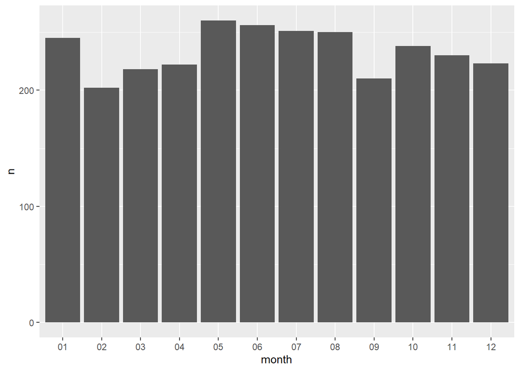

```r
# Save result separately
VisitsPerMonth <- hospital %>% select(month) %>% group_by(month) %>% count(month)

# Draw a bar diagram
ggplot(data=VisitsPerMonth, aes(x=month, y=n)) + geom_bar(stat="identity")
```

## Task 5

```r
patients <- patients %>% mutate(AgeGroup = case_when(
                                           (Age >= 40 & Age <= 49) ~ "40-49"
                                         , (Age >= 50 & Age <= 59) ~ "50-59"
                                         , (Age >= 60 & Age <= 69) ~ "60-69"
                                         , (Age >= 70) ~ "above 70"
                                         , TRUE ~ NA) )

# Show result table
patients %>% filter(TRUE)
```

| Participant_ID | Sex | Age | Smoking_status | BMI | Disease | AgeGroup |
| --- | --- | --- | --- | --- | --- | --- |
| 1003300 | Male | 62 | Previous | 33.75970 | 2 | 60-69 |
| 1004025 | Male | 60 | Previous | 28.11730 | 1 | 60-69 |
| 1005551 | Male | 69 | Previous | 26.41590 | 2 | 60-69 |
| 1005594 | Male | 64 | Previous | 24.75500 | 1 | 60-69 |
| 1005624 | Male | 64 | Previous | 35.07730 | 2 | 60-69 |
| 1008540 | Female | 64 | Previous | 21.67640 | 2 | 60-69 |
| 1008931 | Male | 62 | Previous | 26.95290 | 2 | 60-69 |
| 1010012 | Male | 66 | Never | 33.81260 | 2 | 60-69 |
| 1010841 | Male | 58 | Previous | 30.08260 | 1 | 50-59 |
| 1015236 | Male | 63 | Previous | 23.88040 | 2 | 60-69 |

[output cut: 2200 more lines]

## Task 6

### Merge the two files to include the columns: Patient_ID, Sex, Age, BMI, Smoking_status, Number_of_visits, Disease and age group

```r
patients_overall =
  patients %>%
  left_join(hospitalvisits,
    by = join_by(Participant_ID),
    copy = FALSE,
    keep = NULL
  ) %>%
  mutate(NumberOfVisits = case_when(is.na(NumberOfVisits) ~ 0, TRUE ~ NumberOfVisits))
```

# Statistics

## Task 1

### Compare the BMI between the healthy and control groups using a box or violin plot.

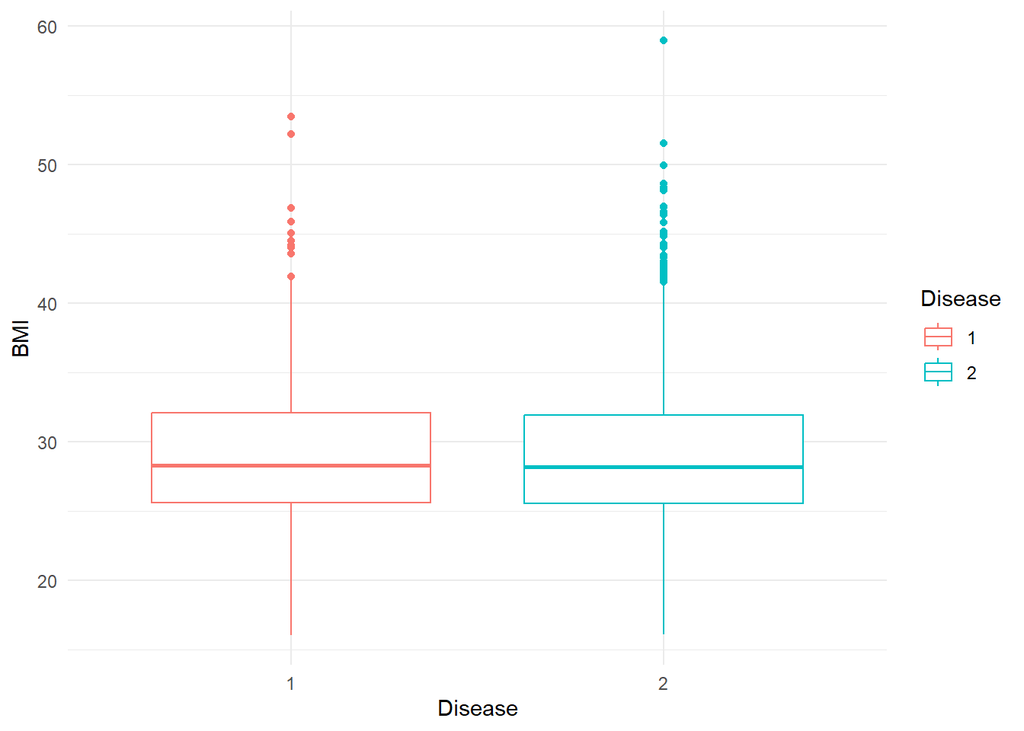

```r
# Convert Disease from numeric to a factor
#  factor 1 means disease, 2 means healthy
patients$Disease <- as.factor(patients$Disease)

# Draw a boxplot
ggplot(data=patients,aes(x=Disease, y=BMI, color=Disease)) + geom_boxplot() +theme_minimal()
```

Conclusion: The BMI results between patients with and without a disease look mostly the same. There is no obvious difference. Median, upper and lower quartile etc. are nearly the same.

## Task 2

### Examine if the proportion of smoking status differs between the healthy and control groups.

Chi-square test

```r
#  factor 1 means disease, 2 means healthy
patients_chi <- table(patients$Disease, patients$Smoking_status)
#Table of Disease and smoking status:
print(patients_chi)
```

```
##
##     Current Never Prefer not to answer Previous
##   1      92   214                    5      254
##   2     258   635                    4      748
```

```r
chi_squared_test <- chisq.test(patients_chi)
#Chi-Squared Test Results:
print(chi_squared_test)
```

```
##
##  Pearson's Chi-squared test
##
## data:  patients_chi
## X-squared = 4.4313, df = 3, p-value = 0.2185
```

Conclusion: The p-value is not less than 0.05, which indicates, that there is NO significant difference in smoking status between the compared groups.

## Task 3

### Analyze the relationship between smoking status and the number of hospital visits, separately for the disease and healthy groups, and for the overall population.

ANOVA Test

```r
#  factor 1 means disease, 2 means healthy

#H0: There is no dependency between the smoking status and the number of visits
#Ha: There is an significant influence of the smoking status on the number of hospital visits.

# ANOVA for each group
anova_healthy <- aov(NumberOfVisits ~ Smoking_status, data = patients_overall %>% filter(Disease == 2))
anova_disease <- aov(NumberOfVisits ~ Smoking_status, data = patients_overall %>% filter(Disease == 1))
anova_overall <- aov(NumberOfVisits ~ Smoking_status, data = patients_overall )

#ANOVA Results per Group:
summary(anova_healthy)
```

```
##                  Df Sum Sq Mean Sq F value Pr(>F)
## Smoking_status    3    0.1  0.0492   0.137  0.938
## Residuals      1641  591.1  0.3602
```

```r
summary(anova_disease)
```

```
##                 Df Sum Sq Mean Sq F value Pr(>F)
## Smoking_status   3   1.32  0.4405    1.26  0.287
## Residuals      561 196.17  0.3497
```

```r
summary(anova_overall)
```

```
##                  Df Sum Sq Mean Sq F value Pr(>F)
## Smoking_status    3    0.5  0.1654   0.463  0.708
## Residuals      2206  788.2  0.3573
```

The p-value (Pr(>F)) of all three tests differs quite a lot, but none of the p-values is below 0.05. Therefor there is no significant dependency between the smoking status and the number of hospital visits. You can reject Ha.

## Task 4

### Determine if the number of visits is higher in the disease group compared to the healthy group.

H0: The number of visits in the disease group is not higher than in the healthy group

Ha: The number of visits in the disease group is higher/greater than in the healthy group

```r
patients_overall %>% select(Disease, NumberOfVisits) %>% group_by(Disease) %>% get_summary_stats(NumberOfVisits, type = "mean_sd")
```

| Disease | variable | n | mean | sd |
| --- | --- | --- | --- | --- |
| 1 | NumberOfVisits | 565 | 0.356 | 0.592 |
| 2 | NumberOfVisits | 1645 | 0.356 | 0.600 |

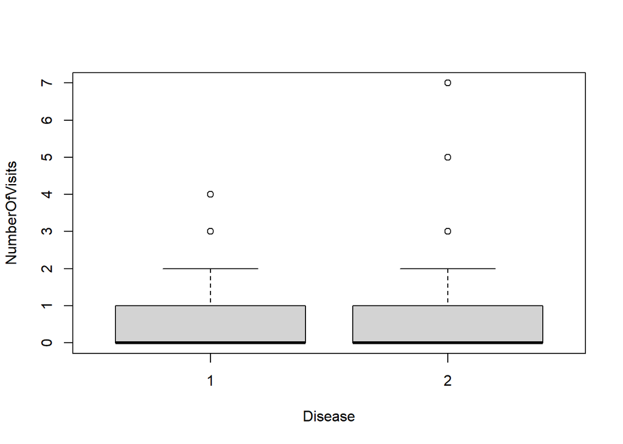

```r
boxplot(NumberOfVisits~Disease, data=patients_overall)
```

```r
t_test <- t.test(NumberOfVisits ~ Disease, data = patients_overall, alternative = "greater" )


print(t_test)
```

```
##
##  Welch Two Sample t-test
##
## data:  NumberOfVisits by Disease
## t = -0.016536, df = 989.84, p-value = 0.5066
## alternative hypothesis: true difference in means between group 1 and group 2 is greater than 0
## 95 percent confidence interval:
##  -0.04815008         Inf
## sample estimates:
## mean in group 1 mean in group 2
##       0.3557522       0.3562310
```

Conclusion: The summary, as well as the boxplot show pretty much no difference in mean-values. The p-value is not below 0.05. You can reject Ha.

## Task 5

### Calculate the disease prevalence (number of sick / total number population) across different age groups in our dataset, and test if the prevalence is different across the group

```r
#  factor 1 means disease, 2 means healthy

# get the number of people with disease (disease == 1) per AgeGroup
DiseasePerAgeGroup <- patients_overall %>% group_by(AgeGroup) %>% filter(Disease == 1) %>% count(Disease)

# calculate the prevelance per AgeGroup
DiseasePrevelance <-
  patients_overall %>%
    group_by(AgeGroup) %>%
    summarise(Total = n()) %>%
    left_join(DiseasePerAgeGroup,
              by = join_by(AgeGroup),
              copy = FALSE,
              keep = NULL
              ) %>%
    select(AgeGroup, Total, n) %>%
    mutate(prevelance = n/Total)


#prevelance_chi <- table(DiseasePrevelance$AgeGroup, DiseasePrevelance$prevelance)
#Table of AgeGroup and prevelance:
#print(prevelance_chi)
#chi_squared_test_prevelance <- chisq.test(prevelance_chi)

#Chi-Squared Test Results:
#print(chi_squared_test_prevelance)

disease_chi <- table(patients$AgeGroup, patients$Disease)
#Table of AgeGroup and DiseaseStatus:
print(disease_chi)
```

```
##
##               1    2
##   40-49      42  113
##   50-59     108  389
##   60-69     407 1116
##   above 70    8   27
```

```r
chi_squared_test_disease <- chisq.test(disease_chi)

#Chi-Squared Test Results:
print(chi_squared_test_disease)
```

```
##
##  Pearson's Chi-squared test
##
## data:  disease_chi
## X-squared = 5.2406, df = 3, p-value = 0.155
```

Conclusion: The p-value is above 0.05 so there is no significant relationship between disease status and AgeGroup.